# ICMA D2SC Notebook

# ICMA Sept 18th 2024

```r
?ChickWeight
glimpse(ChickWeight)
```

```
## Rows: 578
## Columns: 4
## $ weight <dbl> 42, 51, 59, 64, 76, 93, 106, 125, 149, 171, 199, 205, 40, 49, 5…
## $ Time   <dbl> 0, 2, 4, 6, 8, 10, 12, 14, 16, 18, 20, 21, 0, 2, 4, 6, 8, 10, 1…
## $ Chick  <ord> 1, 1, 1, 1, 1, 1, 1, 1, 1, 1, 1, 1, 2, 2, 2, 2, 2, 2, 2, 2, 2, …
## $ Diet   <fct> 1, 1, 1, 1, 1, 1, 1, 1, 1, 1, 1, 1, 1, 1, 1, 1, 1, 1, 1, 1, 1, …
```

```r
chick_clean <- ChickWeight %>%
  select(chick_id = Chick,
         diet = Diet,
         age_days = Time,
         weight_gm = weight)
```

mutate() also has it’s own if/then type capability that can be useful: case_when()

```r
chick_clean %>%
  mutate(session = case_when(age_days == 0 ~ "birth",
                             age_days == 20 ~ "last1",
                             age_days ==21 ~ "last2",
                             TRUE          ~as.character(age_days)))
```

|  | chick_id | diet | age_days | weight_gm | session |
| --- | --- | --- | --- | --- | --- |
| 1 | 1 | 1 | 0 | 42 | birth |
| 2 | 1 | 1 | 2 | 51 | 2 |
| 3 | 1 | 1 | 4 | 59 | 4 |
| 4 | 1 | 1 | 6 | 64 | 6 |
| 5 | 1 | 1 | 8 | 76 | 8 |
| 6 | 1 | 1 | 10 | 93 | 10 |
| 7 | 1 | 1 | 12 | 106 | 12 |
| 8 | 1 | 1 | 14 | 125 | 14 |
| 9 | 1 | 1 | 16 | 149 | 16 |
| 10 | 1 | 1 | 18 | 171 | 18 |

[output cut: 568 more lines]

```r
chick_clean %>%
  filter(age_days == 20) %>%
  mutate(weight_lbs = weight_gm/453.6) %>%
  group_by(diet) %>%
  summarise(N = n(),
            mean_wgt_gm = mean(weight_gm),
            mean_wgt_lbs = mean(weight_lbs))
```

| diet | N | mean_wgt_gm | mean_wgt_lbs |
| --- | --- | --- | --- |
| 1 | 17 | 170.4118 | 0.3756873 |
| 2 | 10 | 205.6000 | 0.4532628 |
| 3 | 10 | 258.9000 | 0.5707672 |
| 4 | 9 | 233.8889 | 0.5156281 |

# ICMA Sept 23 2024

Five main types of functions in tidyr: - Pivoting: Converts between long and wide forms - Splitting and combining: take character columns and split/combine them - Missing values: For working with NAs (missing values) - Rectangling: Turns deeply nested lists (as from JSON) into tidy tibbles - (Un)Nesting: Converts between grouped data and a form where each group becomes a single row containing a nested data frame

```r
head(billboard)
```

| artist | track | date.entered | wk1 | wk2 | wk3 | wk4 | wk5 | wk6 | wk7 | wk8 | wk9 | wk10 | wk11 | wk12 | wk13 | wk14 | wk15 | wk16 | wk17 | wk18 | wk19 | wk20 | wk21 | wk22 | wk23 | wk24 | wk25 | wk26 | wk27 | … |
| --- | --- | --- | --- | --- | --- | --- | --- | --- | --- | --- | --- | --- | --- | --- | --- | --- | --- | --- | --- | --- | --- | --- | --- | --- | --- | --- | --- | --- | --- | --- |
| 2 Pac | Baby Don't Cry (Keep... | 2000-02-26 | 87 | 82 | 72 | 77 | 87 | 94 | 99 | NA | NA | NA | NA | NA | NA | NA | NA | NA | NA | NA | NA | NA | NA | NA | NA | NA | NA | NA | NA | … |
| 2Ge+her | The Hardest Part Of ... | 2000-09-02 | 91 | 87 | 92 | NA | NA | NA | NA | NA | NA | NA | NA | NA | NA | NA | NA | NA | NA | NA | NA | NA | NA | NA | NA | NA | NA | NA | NA | … |
| 3 Doors Down | Kryptonite | 2000-04-08 | 81 | 70 | 68 | 67 | 66 | 57 | 54 | 53 | 51 | 51 | 51 | 51 | 47 | 44 | 38 | 28 | 22 | 18 | 18 | 14 | 12 | 7 | 6 | 6 | 6 | 5 | 5 | … |
| 3 Doors Down | Loser | 2000-10-21 | 76 | 76 | 72 | 69 | 67 | 65 | 55 | 59 | 62 | 61 | 61 | 59 | 61 | 66 | 72 | 76 | 75 | 67 | 73 | 70 | NA | NA | NA | NA | NA | NA | NA | … |
| 504 Boyz | Wobble Wobble | 2000-04-15 | 57 | 34 | 25 | 17 | 17 | 31 | 36 | 49 | 53 | 57 | 64 | 70 | 75 | 76 | 78 | 85 | 92 | 96 | NA | NA | NA | NA | NA | NA | NA | NA | NA | … |
| 98^0 | Give Me Just One Nig... | 2000-08-19 | 51 | 39 | 34 | 26 | 26 | 19 | 2 | 2 | 3 | 6 | 7 | 22 | 29 | 36 | 47 | 67 | 66 | 84 | 93 | 94 | NA | NA | NA | NA | NA | NA | NA | … |

```r
billboard_long <- billboard %>%
  pivot_longer(wk1:wk76,
               names_to = "week",
               values_to = "position",
               names_prefix = "wk",
               values_drop_na = TRUE)
```

```r
# reversing it back to wide format
billboard_long %>%
  pivot_wider(names_from = "week",
              values_from = "position")
```

| artist | track | date.entered | 1 | 2 | 3 | 4 | 5 | 6 | 7 | 8 | 9 | 10 | 11 | 12 | 13 | 14 | 15 | 16 | 17 | 18 | 19 | 20 | 21 | 22 | 23 | 24 | 25 | 26 | 27 | … |
| --- | --- | --- | --- | --- | --- | --- | --- | --- | --- | --- | --- | --- | --- | --- | --- | --- | --- | --- | --- | --- | --- | --- | --- | --- | --- | --- | --- | --- | --- | --- |
| 2 Pac | Baby Don't Cry (Keep... | 2000-02-26 | 87 | 82 | 72 | 77 | 87 | 94 | 99 | NA | NA | NA | NA | NA | NA | NA | NA | NA | NA | NA | NA | NA | NA | NA | NA | NA | NA | NA | NA | … |
| 2Ge+her | The Hardest Part Of ... | 2000-09-02 | 91 | 87 | 92 | NA | NA | NA | NA | NA | NA | NA | NA | NA | NA | NA | NA | NA | NA | NA | NA | NA | NA | NA | NA | NA | NA | NA | NA | … |
| 3 Doors Down | Kryptonite | 2000-04-08 | 81 | 70 | 68 | 67 | 66 | 57 | 54 | 53 | 51 | 51 | 51 | 51 | 47 | 44 | 38 | 28 | 22 | 18 | 18 | 14 | 12 | 7 | 6 | 6 | 6 | 5 | 5 | … |
| 3 Doors Down | Loser | 2000-10-21 | 76 | 76 | 72 | 69 | 67 | 65 | 55 | 59 | 62 | 61 | 61 | 59 | 61 | 66 | 72 | 76 | 75 | 67 | 73 | 70 | NA | NA | NA | NA | NA | NA | NA | … |
| 504 Boyz | Wobble Wobble | 2000-04-15 | 57 | 34 | 25 | 17 | 17 | 31 | 36 | 49 | 53 | 57 | 64 | 70 | 75 | 76 | 78 | 85 | 92 | 96 | NA | NA | NA | NA | NA | NA | NA | NA | NA | … |
| 98^0 | Give Me Just One Nig... | 2000-08-19 | 51 | 39 | 34 | 26 | 26 | 19 | 2 | 2 | 3 | 6 | 7 | 22 | 29 | 36 | 47 | 67 | 66 | 84 | 93 | 94 | NA | NA | NA | NA | NA | NA | NA | … |
| A*Teens | Dancing Queen | 2000-07-08 | 97 | 97 | 96 | 95 | 100 | NA | NA | NA | NA | NA | NA | NA | NA | NA | NA | NA | NA | NA | NA | NA | NA | NA | NA | NA | NA | NA | NA | … |
| Aaliyah | I Don't Wanna | 2000-01-29 | 84 | 62 | 51 | 41 | 38 | 35 | 35 | 38 | 38 | 36 | 37 | 37 | 38 | 49 | 61 | 63 | 62 | 67 | 83 | 86 | NA | NA | NA | NA | NA | NA | NA | … |
| Aaliyah | Try Again | 2000-03-18 | 59 | 53 | 38 | 28 | 21 | 18 | 16 | 14 | 12 | 10 | 9 | 8 | 6 | 1 | 2 | 2 | 2 | 2 | 3 | 4 | 5 | 5 | 6 | 9 | 13 | 14 | 16 | … |
| Adams, Yolanda | Open My Heart | 2000-08-26 | 76 | 76 | 74 | 69 | 68 | 67 | 61 | 58 | 57 | 59 | 66 | 68 | 61 | 67 | 59 | 63 | 67 | 71 | 79 | 89 | NA | NA | NA | NA | NA | NA | NA | … |

[output cut: 307 more lines]

```r
?pivot_longer
```

```r
billboard %>%
  separate(col = date.entered,
           into = c("year", "month", "day"))
```

| artist | track | year | month | day | wk1 | wk2 | wk3 | wk4 | wk5 | wk6 | wk7 | wk8 | wk9 | wk10 | wk11 | wk12 | wk13 | wk14 | wk15 | wk16 | wk17 | wk18 | wk19 | wk20 | wk21 | wk22 | wk23 | wk24 | wk25 | … |
| --- | --- | --- | --- | --- | --- | --- | --- | --- | --- | --- | --- | --- | --- | --- | --- | --- | --- | --- | --- | --- | --- | --- | --- | --- | --- | --- | --- | --- | --- | --- |
| 2 Pac | Baby Don't Cry (Keep... | 2000 | 02 | 26 | 87 | 82 | 72 | 77 | 87 | 94 | 99 | NA | NA | NA | NA | NA | NA | NA | NA | NA | NA | NA | NA | NA | NA | NA | NA | NA | NA | … |
| 2Ge+her | The Hardest Part Of ... | 2000 | 09 | 02 | 91 | 87 | 92 | NA | NA | NA | NA | NA | NA | NA | NA | NA | NA | NA | NA | NA | NA | NA | NA | NA | NA | NA | NA | NA | NA | … |
| 3 Doors Down | Kryptonite | 2000 | 04 | 08 | 81 | 70 | 68 | 67 | 66 | 57 | 54 | 53 | 51 | 51 | 51 | 51 | 47 | 44 | 38 | 28 | 22 | 18 | 18 | 14 | 12 | 7 | 6 | 6 | 6 | … |
| 3 Doors Down | Loser | 2000 | 10 | 21 | 76 | 76 | 72 | 69 | 67 | 65 | 55 | 59 | 62 | 61 | 61 | 59 | 61 | 66 | 72 | 76 | 75 | 67 | 73 | 70 | NA | NA | NA | NA | NA | … |
| 504 Boyz | Wobble Wobble | 2000 | 04 | 15 | 57 | 34 | 25 | 17 | 17 | 31 | 36 | 49 | 53 | 57 | 64 | 70 | 75 | 76 | 78 | 85 | 92 | 96 | NA | NA | NA | NA | NA | NA | NA | … |
| 98^0 | Give Me Just One Nig... | 2000 | 08 | 19 | 51 | 39 | 34 | 26 | 26 | 19 | 2 | 2 | 3 | 6 | 7 | 22 | 29 | 36 | 47 | 67 | 66 | 84 | 93 | 94 | NA | NA | NA | NA | NA | … |
| A*Teens | Dancing Queen | 2000 | 07 | 08 | 97 | 97 | 96 | 95 | 100 | NA | NA | NA | NA | NA | NA | NA | NA | NA | NA | NA | NA | NA | NA | NA | NA | NA | NA | NA | NA | … |
| Aaliyah | I Don't Wanna | 2000 | 01 | 29 | 84 | 62 | 51 | 41 | 38 | 35 | 35 | 38 | 38 | 36 | 37 | 37 | 38 | 49 | 61 | 63 | 62 | 67 | 83 | 86 | NA | NA | NA | NA | NA | … |
| Aaliyah | Try Again | 2000 | 03 | 18 | 59 | 53 | 38 | 28 | 21 | 18 | 16 | 14 | 12 | 10 | 9 | 8 | 6 | 1 | 2 | 2 | 2 | 2 | 3 | 4 | 5 | 5 | 6 | 9 | 13 | … |
| Adams, Yolanda | Open My Heart | 2000 | 08 | 26 | 76 | 76 | 74 | 69 | 68 | 67 | 61 | 58 | 57 | 59 | 66 | 68 | 61 | 67 | 59 | 63 | 67 | 71 | 79 | 89 | NA | NA | NA | NA | NA | … |

[output cut: 307 more lines]

# ICMA Sept 25 2024

```r
head(ChickWeight)
```

|  | weight | Time | Chick | Diet |
| --- | --- | --- | --- | --- |
| 1 | 42 | 0 | 1 | 1 |
| 2 | 51 | 2 | 1 | 1 |
| 3 | 59 | 4 | 1 | 1 |
| 4 | 64 | 6 | 1 | 1 |
| 5 | 76 | 8 | 1 | 1 |
| 6 | 93 | 10 | 1 | 1 |

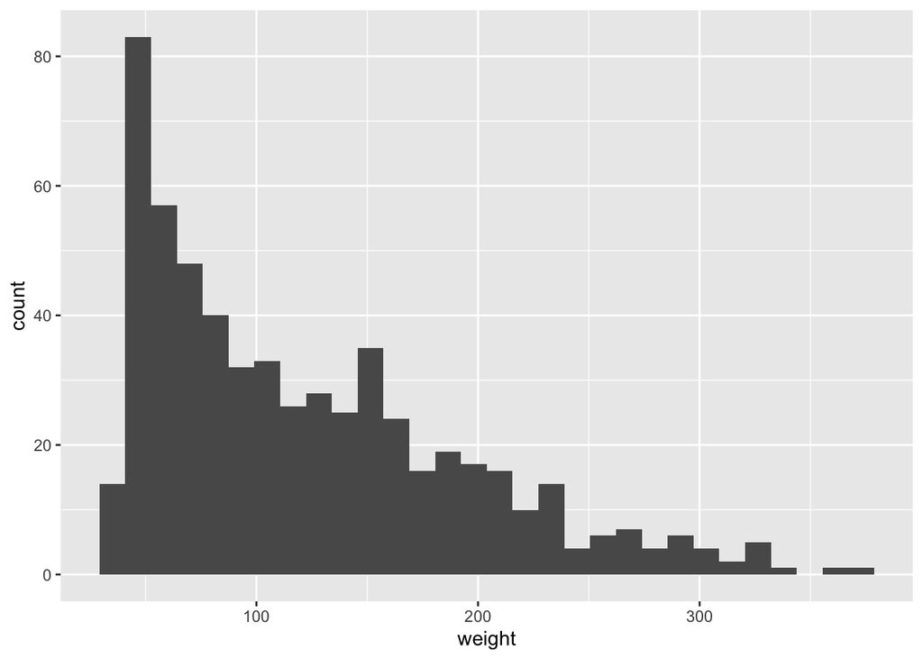

```r
ChickWeight %>%
  ggplot(aes(x = weight)) + #provide the aesthetic mapping
  geom_histogram() #tell ggplot which geometry to use, in this case a histogram
```

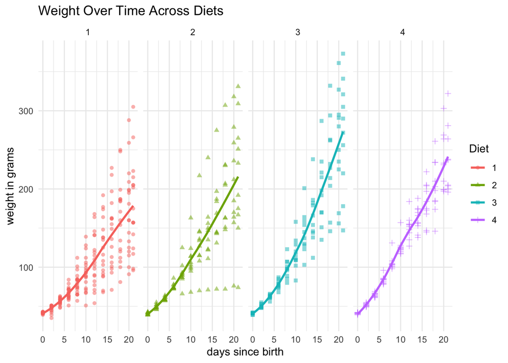

```r
ChickWeight %>%
  ggplot(aes(y = weight,
             x = Time,
             color = Diet,
             shape = Diet)) +
  geom_point(alpha = 0.5) +
  geom_smooth(se = FALSE) +
  theme_minimal() +
  facet_grid(~Diet) + #faceting by diet groups
  labs(y = "weight in grams",
       x = "days since birth",
       title = "Weight Over Time Across Diets")
```

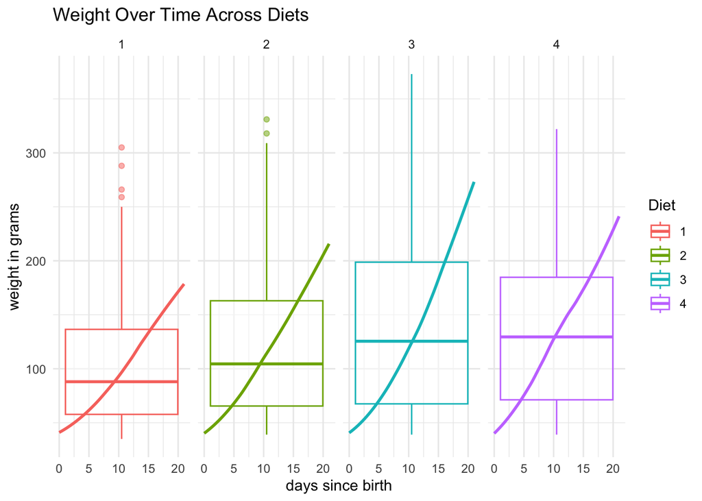

```r
ChickWeight %>%
  ggplot(aes(y = weight,
             x = Time,
             color = Diet,
             shape = Diet)) +
  geom_boxplot(alpha = 0.5) +
  geom_smooth(se = FALSE) +
  theme_minimal() +
  facet_grid(~Diet) + #faceting by diet groups
  labs(y = "weight in grams",
       x = "days since birth",
       title = "Weight Over Time Across Diets")
```

# ICMA Oct 7 2024

```r
as.numeric(12)
```

```
## [1] 12
```

```r
is.numeric(mean(c(12, 31, 15.57, 4)))
```

```
## [1] TRUE
```

```r
# prediction = TRUE
```

```r
((1 + 2) < -1000) | (TRUE & NA)
```

```
## [1] NA
```

```r
(2 + 3 + 9 - 4 == 2 + 6 + as.integer("2.9")) & TRUE | NA
```

```
## [1] TRUE
```

# ICMA Oct 9 2024

```r
my_number <- 12
```

```r
age_data <- tribble(
  ~ id, ~ age,
  1, 8,
  2, 10,
  3, 8,
  5, 9
)

gender_data <- tribble(
  ~ id, ~ gender,
  1, "f",
  2, "m",
  3, "nb",
  4, "m",
  6, "f"
)
```

```r
age_data
```

| id | age |
| --- | --- |
| 1 | 8 |
| 2 | 10 |
| 3 | 8 |
| 5 | 9 |

```r
gender_data
```

| id | gender |
| --- | --- |
| 1 | f |
| 2 | m |
| 3 | nb |
| 4 | m |
| 6 | f |

```r
full_join(age_data, gender_data)
```

| id | age | gender |
| --- | --- | --- |
| 1 | 8 | f |
| 2 | 10 | m |
| 3 | 8 | nb |
| 5 | 9 | NA |
| 4 | NA | m |
| 6 | NA | f |

```r
right_join(age_data, gender_data)
```

| id | age | gender |
| --- | --- | --- |
| 1 | 8 | f |
| 2 | 10 | m |
| 3 | 8 | nb |
| 4 | NA | m |
| 6 | NA | f |

```r
left_join(age_data, gender_data)
```

| id | age | gender |
| --- | --- | --- |
| 1 | 8 | f |
| 2 | 10 | m |
| 3 | 8 | nb |
| 5 | 9 | NA |

```r
inner_join(age_data, gender_data)
```

| id | age | gender |
| --- | --- | --- |
| 1 | 8 | f |
| 2 | 10 | m |
| 3 | 8 | nb |

# ICMA Oct 16 2024

```r
mean(c(1, 2, 3))
```

```
## [1] 2
```

```r
(1 + 2 + 3)/3
```

```
## [1] 2
```

```r
vec <- c(1, 2, 3)
```

```r
(vec[1] + vec[2] + vec[3])/length(vec)
```

```
## [1] 2
```

```r
fave_number <- tribble(~name, ~number,
                       "MC", 8,
                       "AP", 9,
                       "NG", 12,
                       "VE", 6,
                       "AL", 17,
                       "AR", 3,
                       "MC", 7,
                       "RK", 8,
                       "AC", 4,
                       "SC", 21,
                       "KK", 16,
                       "RK", 28,
                       "VK", 17,
                       "MH", 12
                       )
```

```r
for (i in fave_number) {
  print(i)
}
```

```
##  [1] "MC" "AP" "NG" "VE" "AL" "AR" "MC" "RK" "AC" "SC" "KK" "RK" "VK" "MH"
##  [1]  8  9 12  6 17  3  7  8  4 21 16 28 17 12
```

```r
for (i in fave_number$number) {
  print(i)
}
```

```
## [1] 8
## [1] 9
## [1] 12
## [1] 6
## [1] 17
## [1] 3
## [1] 7
## [1] 8
## [1] 4
## [1] 21
## [1] 16
## [1] 28
## [1] 17
## [1] 12
```

How are fave_number[“number”] and fave_number$number different?

```r
typeof(fave_number["number"])
```

```
## [1] "list"
```

```r
typeof(fave_number$number)
```

```
## [1] "double"
```

```r
for (i in fave_number[["number"]]) {
  print(i)
}
```

```
## [1] 8
## [1] 9
## [1] 12
## [1] 6
## [1] 17
## [1] 3
## [1] 7
## [1] 8
## [1] 4
## [1] 21
## [1] 16
## [1] 28
## [1] 17
## [1] 12
```

```r
for (i in seq_along(fave_number$name)) {
  print(str_c(fave_number$name[i], "'s favorite number is ", fave_number$number[i]))
}
```

```
## [1] "MC's favorite number is 8"
## [1] "AP's favorite number is 9"
## [1] "NG's favorite number is 12"
## [1] "VE's favorite number is 6"
## [1] "AL's favorite number is 17"
## [1] "AR's favorite number is 3"
## [1] "MC's favorite number is 7"
## [1] "RK's favorite number is 8"
## [1] "AC's favorite number is 4"
## [1] "SC's favorite number is 21"
## [1] "KK's favorite number is 16"
## [1] "RK's favorite number is 28"
## [1] "VK's favorite number is 17"
## [1] "MH's favorite number is 12"
```

# ICMA Oct 30 2024

Let’s write a sentence that has **bold** and *italics*!

Part 2: create a variable, then write a sentence that uses that variable, bold, and italics

```r
name <- "Vidushi"
```

My name is Vidushi and I really hate it when people use both **bold** and *italics* in the same sentence.

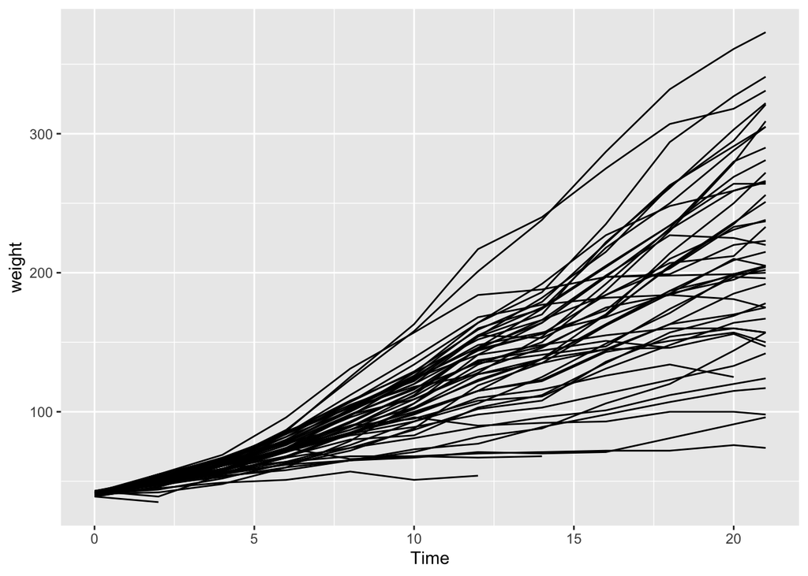

Chick weight across time

```r
ChickWeight %>%
  ggplot(aes(y = weight, x = Time, group = Chick)) +
  geom_line()
```